# When can an LLM output support a sociological claim?

Session 1 · Generative AI in Sociology

Christopher Barrie · NYU Sociology

2026-09-02

## Our question for today

When can an LLM output support a sociological claim?

We will follow one small example from the original text, through a model call, to the record we would need for research.

## How are you using AI now?

01 Where are you already using AI in research or teaching?

02 What has it made easier?

03 What might you stop learning if the operation becomes invisible?

## AI use is permitted - with responsibility and disclosure

Use it

to question, explore, debug, compare and revise.

You remain responsible

for every claim and every line of submitted code.

You must be able to explain what the code does, what the model returned, and what you learned or failed to learn by using AI.

## We begin with one sentence

Source text

> “You can never be too careful when dealing with people.”

This is our input. It is a sentence from a familiar survey question about generalized trust.

## The first Python object is the text itself

```python
source_text = (
    "You can never be too careful "
    "when dealing with people."
)

print(source_text)
print(type(source_text))
```

Printed output

```
You can never be too careful when dealing with people.
<class 'str'>
```

**Input:** text **Operation:** assign and inspect **Output type:** string (`str`)

## We ask the model to perform a specific task

Input text

You can never be too careful when dealing with people.

+

Researcher instruction

Score the social trust expressed in the text from 0 (low) to 2 (high).

The model has not discovered our measurement rule. We supplied the task and the scale.

## We can require a response with named fields

Requested structure

```
{
  "trust_score": 0, 1, or 2,
  "reason": "short explanation"
}
```

Illustrative response

```
{
  "trust_score": 0,
  "reason": "The statement expects
             caution toward others."
}
```

A structured output controls the shape of the response. It does not establish that the score measures generalized trust well.

## The same output can be used to make very different claims

**Observed output**The model returned a score of 0.

**Measurement claim**The sentence expresses low generalized trust.

**Validation claim**This procedure measures trust accurately across texts.

**Substantive claim**The people represented by these texts differ in social trust.

## Each stronger claim requires additional evidence

| Claim | Evidence we have | Evidence still needed |
| --- | --- | --- |
| Model returned 0 | Saved response | Exact request and response record |
| Text expresses low trust | One model judgment | Defined construct and coding rule |
| Procedure measures trust | One case | Human reference cases and errors |
| Groups differ in trust | None yet | Sampling, comparison and downstream analysis |

The model output is one object inside a longer research design.

## Sociologists are already using GenAI - mostly outside data collection

[figure not shown]

**Material:** survey of 433 authors who had published in 50 sociology journals.

**Question:** how often, where and why are sociologists using GenAI?

**Finding:** around one third reported at least weekly use; writing assistance was much more common than data collection.

Alvero, Stoltz, Stuhler & Taylor (2026), “Generative AI in Sociological Research: State of the Discipline,” *Sociological Science* 13:45-62. https://doi.org/10.15195/v13.a3.

## Their survey distinguishes everyday use from research stages

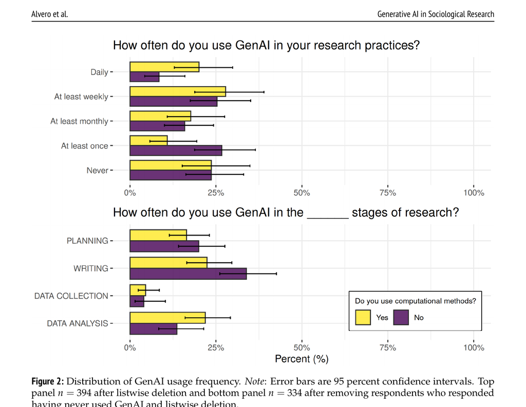

The top panel measures frequency of use.

The bottom panel asks where GenAI enters research.

Writing is the most common research-stage use. Data collection is rare in this survey.

Alvero et al. (2026), Figure 2. Top panel *n* = 394; bottom panel *n* = 334.

## Davidson and Karell organize the new work around three uses

[figure not shown]

**Measurement:** turn records into variables or classifications.

**Prompting:** specify and test the instruction given to the model.

**Simulation:** generate synthetic responses, media or interactions.

Davidson & Karell (2025), “Integrating Generative Artificial Intelligence into Social Science Research,” *Sociological Methods & Research* 54(3):775-793. https://doi.org/10.1177/00491241251339184.

## Their starting point is established measurement practice

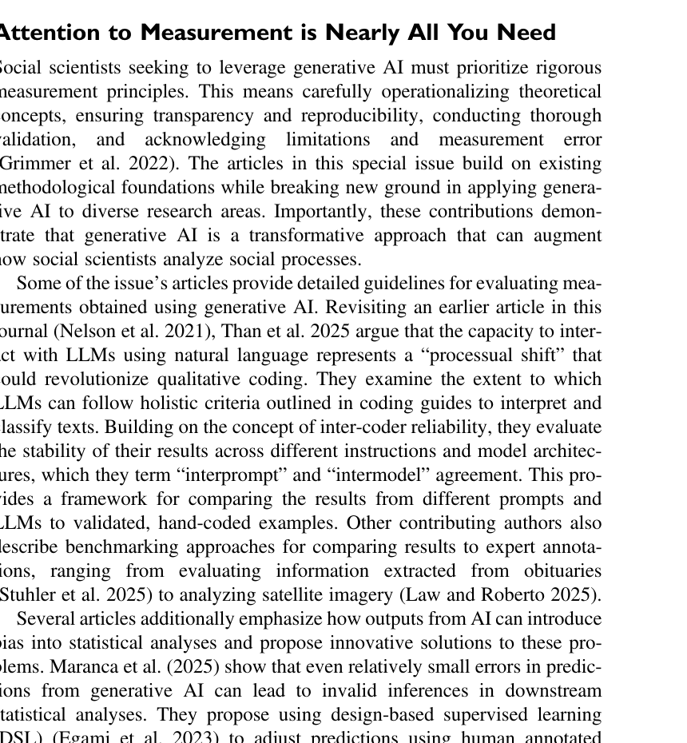

For our example

What is “generalized trust”?

How does the 0-2 rule operationalize it?

Which human-coded cases will test the output?

How could error affect the later comparison?

Davidson & Karell (2025), p. 779. The authors emphasize operationalization, transparency, reproducibility, validation and measurement error.

## The first half of the course follows familiar research operations

**Annotation**Score text for social trustWeek 2

**Qualitative research**Propose themes and retrieve passagesWeek 3

**Observation**Describe images, audio and sequencesWeek 4

**Treatments**Generate or adapt experimental materialWeeks 5-6

## Later sessions ask what happens when models do more of the work

**Synthetic respondents**Generate answers for profilesWeek 7

**Simulation and agents**Generate actions and interactionsWeeks 8-10

**Research agents**Plan, search, use tools and reviseWeeks 11-12

The more of the workflow the system performs, the more important it becomes to preserve the intermediate decisions.

## Faster production changes more than the speed of one task

If AI makes research easier to produce, what happens to the range of questions, methods and people involved in producing knowledge?

Two papers let us separate an empirical pattern from a broader argument about scientific understanding.

## Hao and colleagues study AI use across 41.3 million papers

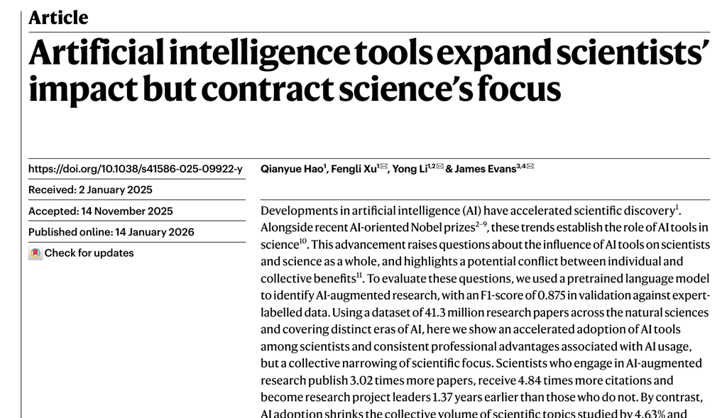

**Material:** natural-science papers from 1980 to 2025.

**Comparison:** papers and researchers identified as using AI tools versus matched non-AI counterparts.

**Question:** how is adoption associated with productivity, impact, careers and the collective range of research?

Hao, Xu, Li et al. (2026), “Artificial intelligence tools expand scientists’ impact but contract science’s focus,” *Nature* 649:1237-1243. https://doi.org/10.1038/s41586-025-09922-y.

## AI adoption is associated with more papers and citations

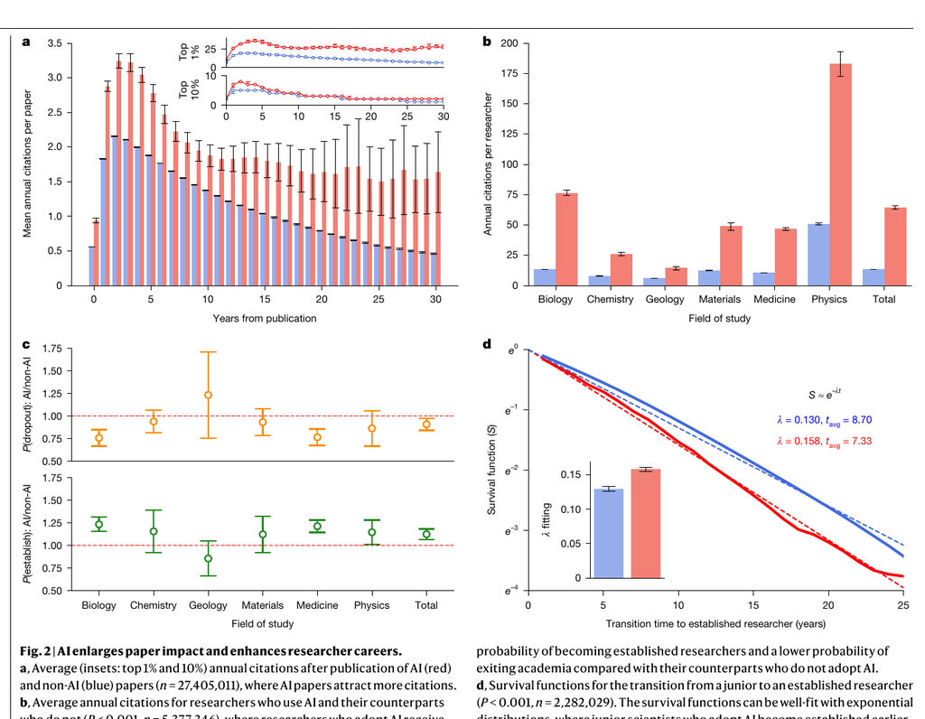

**Read panel b:** across six fields, AI-adopting researchers received more annual citations than the comparison group. The paper also reports 3.02 times more papers per year.

Hao et al. (2026), Figure 2 and Extended Data Figure 4. These are observational associations following identified AI adoption.

## The same study finds a narrower collective knowledge space

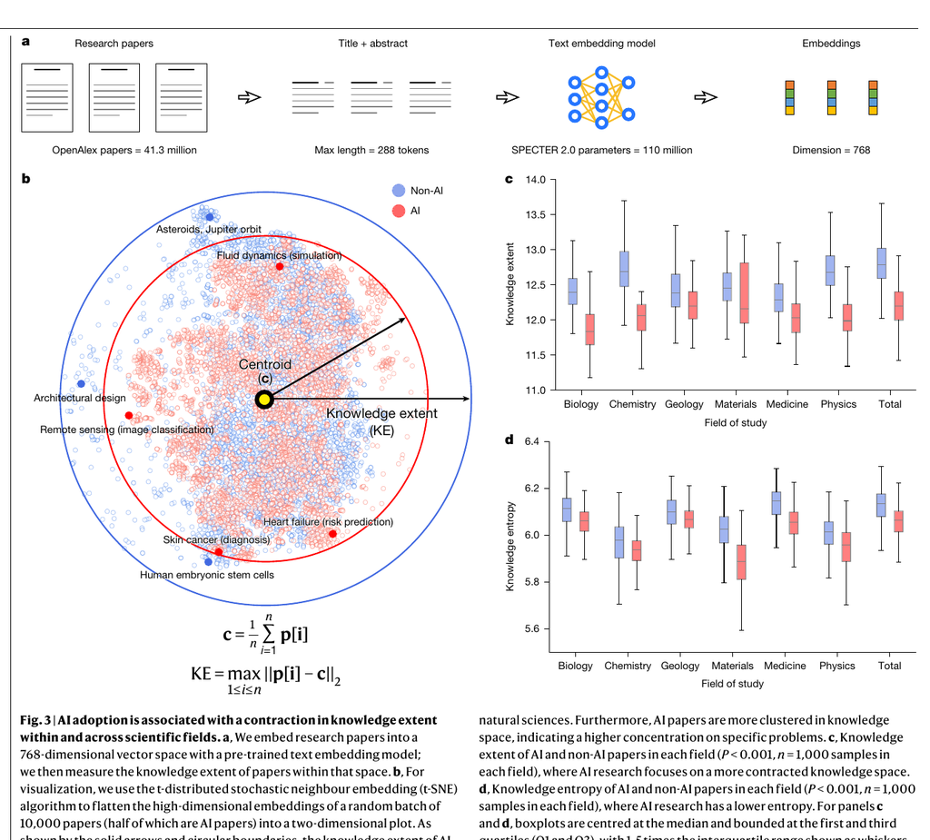

**Read panels b-c:** the red AI-paper distribution occupies a smaller knowledge extent, and the field-level estimates are lower in most disciplines.

Hao et al. (2026), Figure 3. “Knowledge extent” is measured from title and abstract embeddings; it is not a direct measure of scientific understanding.

## Messeri and Crockett ask why AI is so attractive to scientists

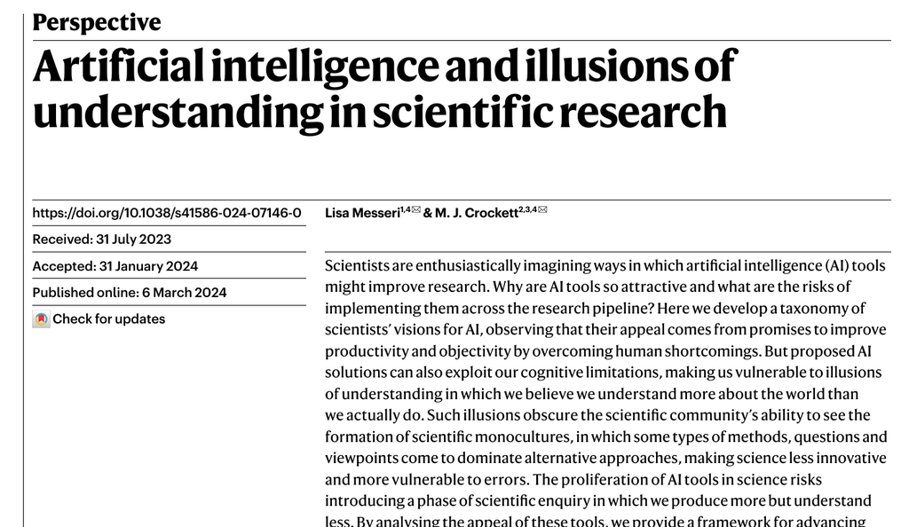

**Type of paper:** a perspective on AI and scientific knowledge production.

**Material:** published visions of AI across the research pipeline.

**Argument:** promises of productivity and objectivity can encourage scientists to trust AI as a knowledge-producing partner.

Messeri & Crockett (2024), “Artificial intelligence and illusions of understanding in scientific research,” *Nature* 627:49-58. https://doi.org/10.1038/s41586-024-07146-0.

## Their argument begins with four recurring visions of AI

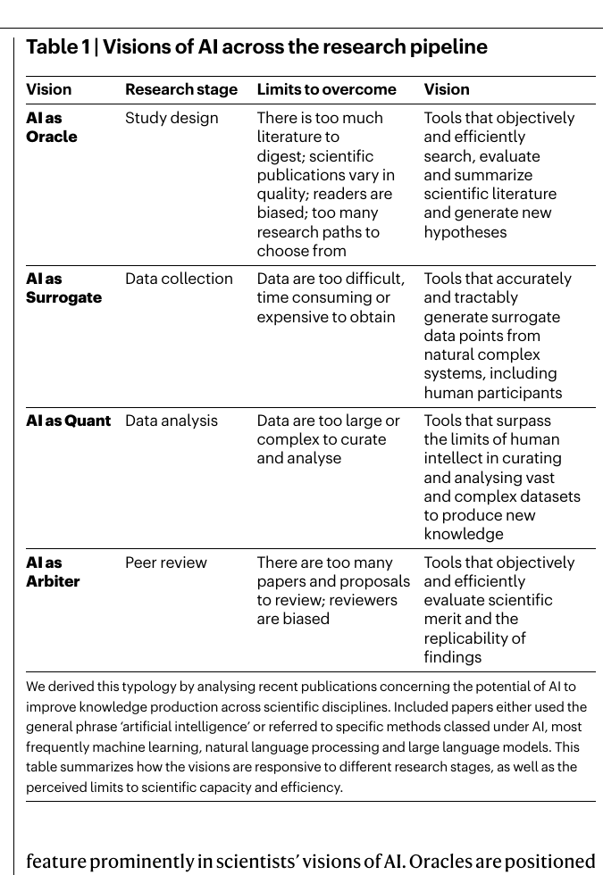

**Oracle:** searches and summarizes.

**Surrogate:** supplies data points.

**Quant:** curates and analyses.

**Arbiter:** evaluates scientific work.

Each vision promises to overcome a limit attributed to human researchers.

Messeri & Crockett (2024), Table 1.

## A good output can encourage a stronger belief than the evidence supports

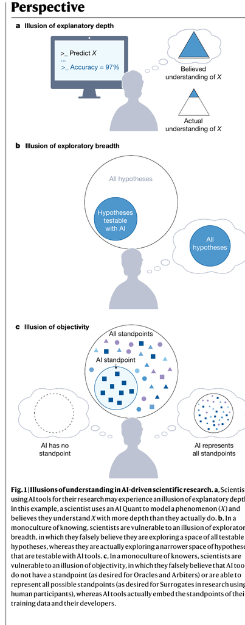

**Explanatory depth:** accurate prediction is mistaken for understanding the mechanism.

**Exploratory breadth:** the questions suited to AI are mistaken for all possible questions.

**Objectivity:** the model’s standpoint is overlooked.

Messeri & Crockett (2024), Figure 1.

## Return to the trust score

```
{"trust_score": 0}
```

It may be a useful proposed code.

It does not tell us whether the construct is well defined.

It does not tell us how the score compares with human judgments.

It does not tell us whether the result will survive another run.

## Suppose the next run returns a different score

Run 1

```
{"trust_score": 0}
```

Run 2

```
{"trust_score": 1}
```

This is a thought experiment, not an observed result. It creates the next question: what should another researcher expect when repeating our procedure?

## We have now shifted from measurement to replication

**Measurement**What does the score represent?

**Replication**What survives a justified repetition?

An unstable measure can change the later substantive finding.

## Barrie, Palmer and Spirling repeat LLM tasks over time

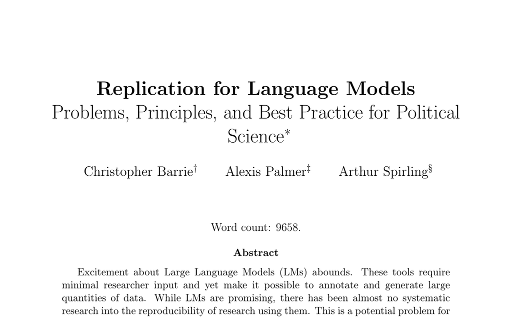

**Design:** a rolling iterated replication using repeated classification tasks.

**Comparisons:** hosted language models, a locally run open model and crowdworkers.

**Outcomes:** accuracy, variation across runs and effects on later statistical estimates.

Barrie, Palmer & Spirling (2025), “Replication for Language Models: Problems, Principles, and Best Practices for Political Science,” working paper, 4 November.

## Their design separates new data from repeated model behavior

**Three tasks**manifestos, protests and populism

**Two samples**a fixed sample and a changing monthly sample

**Repeated runs**the same labeling procedure run many times

**Several sources**hosted LMs, local Llama and crowdworkers

The fixed sample reveals variation produced by the labeling system rather than by changing documents.

## Their typology asks two concrete questions

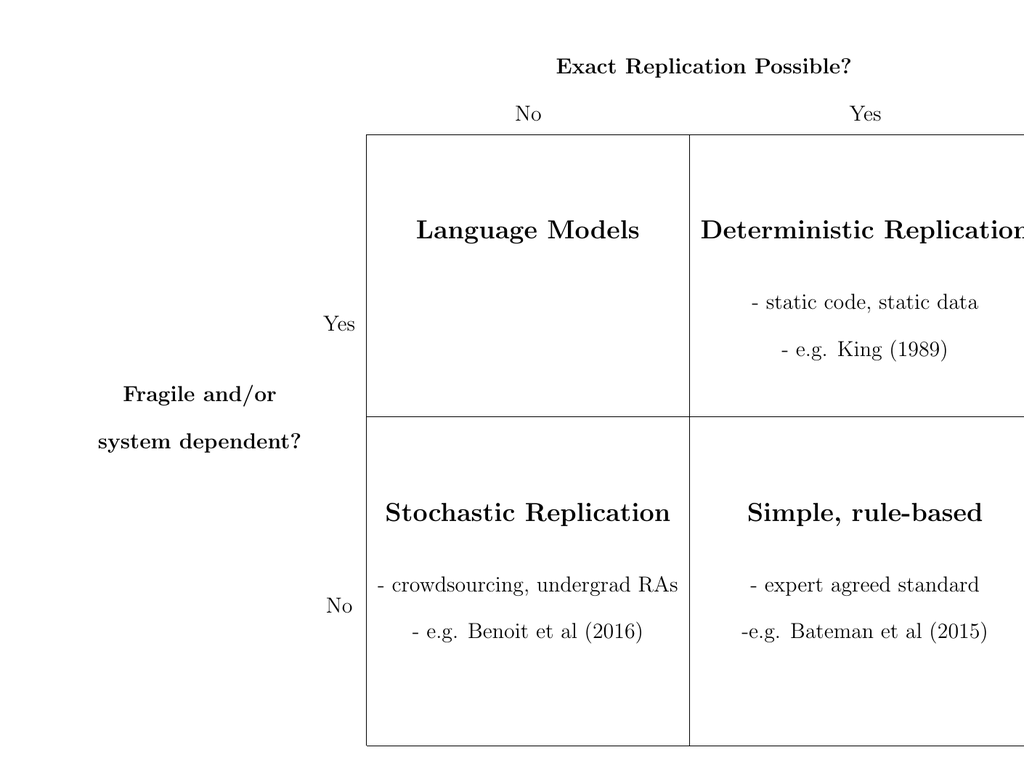

**Language models occupy the upper-left cell:** exact repetition is unavailable, while the result can also depend on a fragile model and service.

Barrie, Palmer & Spirling (2025), Table 1.

## Four words describe different kinds of repetition

| Term | What remains the same? | What are we checking? |
| --- | --- | --- |
| Rerun | Code, data and available system | Can the procedure execute again? |
| Repeat | Task and design | How much do new stochastic outputs vary? |
| Reproduce | Research design | Can an independent implementation recover the result? |
| Replicate | Substantive claim | Does the claim survive new evidence or a new setting? |

Terminology adapted for teaching from Barrie, Palmer & Spirling (2025), sections 2-3.

## High accuracy and low variation are different results

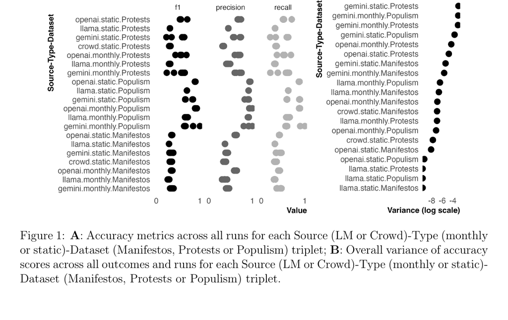

**Panel A:** F1, precision and recall. **Panel B:** variation in those measures across repeated runs. A source can perform well on average and still move between runs.

Barrie, Palmer & Spirling (2025), Figure 1.

## Variation in labels changes later statistical results

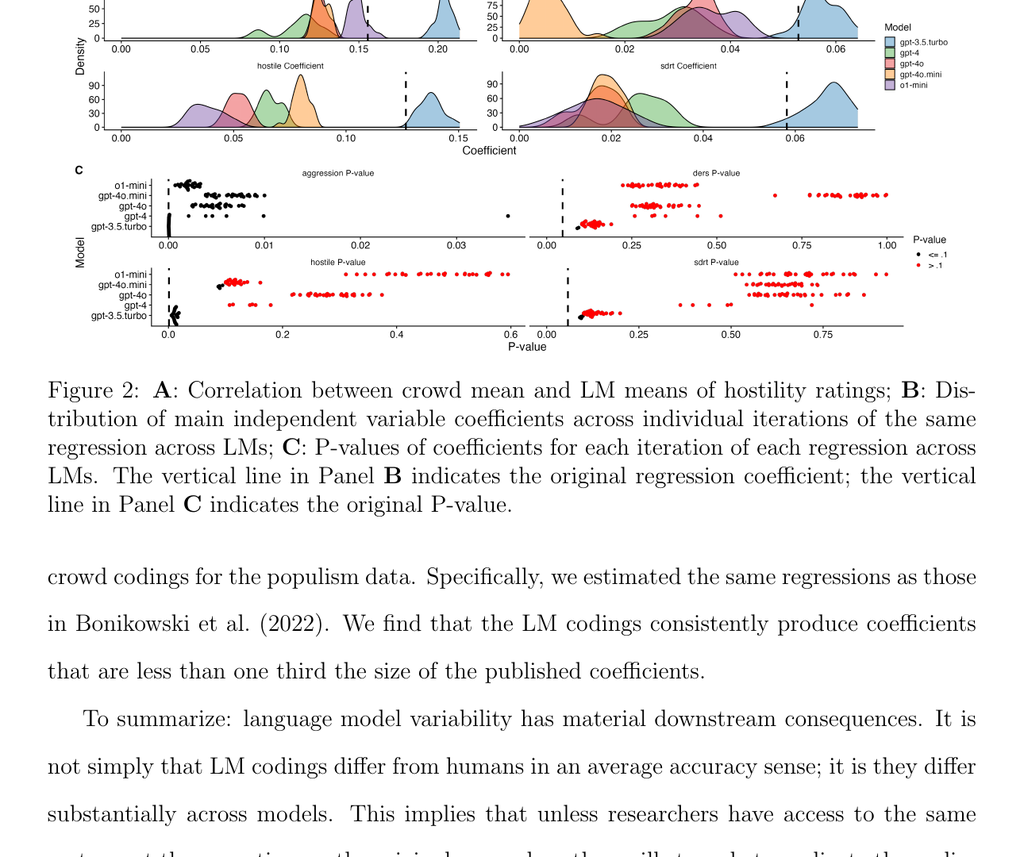

**Panel B:** repeated model codings produce distributions of regression coefficients. **Panel C:** the corresponding p-values can cross conventional thresholds.

Barrie, Palmer & Spirling (2025), Figure 2.

## A local model changes the problem; it does not remove it

|  | Hosted model | Locally versioned model |
| --- | --- | --- |
| Model control | Provider may update or retire it | Weights can be retained |
| Data movement | Requests leave the machine | Requests can remain local |
| Hardware | Provider supplies compute | Your RAM, GPU and storage set limits |
| Environment | Some provider details remain hidden | Runtime and dependencies must be preserved |

Barrie, Palmer and Spirling recommend locally versioned open models when replication is a priority. The record still needs the model files, runtime and settings.

## What would another researcher need from our trust example?

exact source text

task and scale

system and user messages

model, provider and date

settings and schema

raw and parsed response

validation cases

call code

These fields map onto a published reporting standard.

## GUIDE-LLM is a reporting checklist for behavioural science

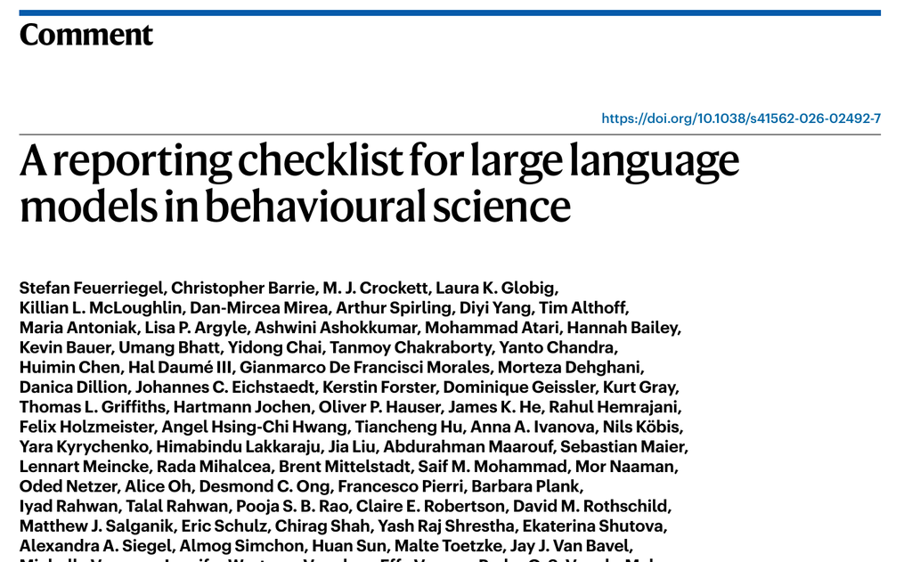

**Type of paper:** consensus-based reporting guidance.

**Development:** a preregistered, two-round Delphi process with 121 experts.

**Purpose:** improve transparency, reproducibility and ethical accountability when LLM use is integral to a study.

Feuerriegel, Barrie, Crockett et al. (2026), “A reporting checklist for large language models in behavioural science,” *Nature Human Behaviour* 10:1182-1186. https://doi.org/10.1038/s41562-026-02492-7.

## The published checklist covers the whole model-use record

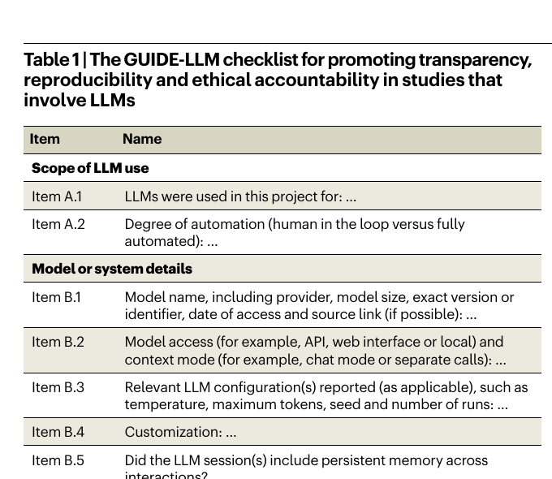

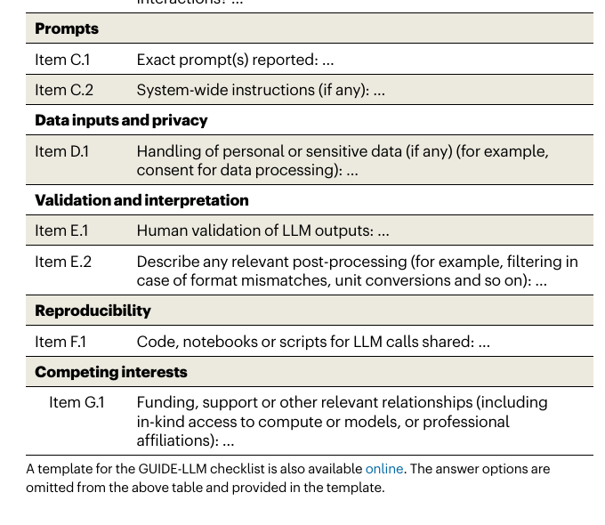

Feuerriegel et al. (2026), Table 1.

## A completed checklist starts with the model’s role and inputs

| Item | Completed course example |
| --- | --- |
| A.1 Role | Propose a 0-2 generalized-trust code for one text. |
| A.2 Automation | Model proposes; researcher defines the scale and reviews the score. |
| B.1 Model | `openai/gpt-5.2`, accessed through OpenRouter on 2 September 2026. |
| B.2 Access | One separate API call from Python; no retained chat history. |
| B.3 Settings | `temperature=0.2`, `max_tokens=80`, one run. |
| C.1-C.2 | Exact system instruction, user instruction, scale and source text saved. |

Instructor-completed teaching example using GUIDE-LLM core items A-C.

## The remaining rows record checking, processing and materials

| Item | Completed course example |
| --- | --- |
| D.1 Privacy | Public survey wording; no participant record sent to the provider. |
| E.1 Validation | Not yet completed; later compare with independently coded cases. |
| E.2 Processing | JSON string converted to a Python dictionary; score retrieved without alteration. |
| F.1 Code | Script, environment information, raw responses and records retained. |
| G.1 Interests | Course access supported through a shared OpenRouter account; disclose material support. |

Instructor-completed teaching example using GUIDE-LLM core items D-G.

## Reporting, reproducibility and validity answer different questions

**Reporting**Can another researcher see what was done?GUIDE-LLM

**Reproducibility**What survives a justified repetition?Barrie, Palmer & Spirling

**Validity**Does the operation support the intended claim?Davidson & Karell

A well-documented output can still be unstable. A stable output can still measure the wrong concept.

## The course workflow comes from those three standards

**1**State the model’s role and intended claim.Davidson-Karell; GUIDE A

**2**Preserve inputs and exact instructions.GUIDE C

**3**Record model, access and settings.GUIDE B

**4**Keep raw output, processing and validation.GUIDE D-E

**5**Share materials and test repetition.GUIDE F; Barrie et al.

## Break

After the break, we will reconstruct the opening model call as Python objects.

## A chat window handles many decisions for you

ChatGPT

Score this text for social trust…

The score is 0.

Message ChatGPT

The interface manages credentials, request formatting and display.

It may retain conversation history and provide tools.

Copying the visible answer does not preserve the full research procedure.

## A Python program makes the request visible

**Terminal**

```
$ python trust_example.py
source_text: 'You can never be too careful...'
type(source_text): <class 'str'>

Sending 2 messages to openai/gpt-5.2...

raw_output: {"trust_score":0,"reason":"The text advises caution."}
type(raw_output): <class 'str'>
trust_score: 0
type(trust_score): <class 'int'>
$ █
```

Illustrative terminal output. A live output may differ and should be saved exactly as returned.

## One call passes through several layers

**Python values**text, messages, settings

*→*

**SDK client**builds the request

*→*

**API service**authenticates and routes

*→*

**Model**generates tokens

*→*

**Response**text plus metadata

extract*→*parse*→*validate*→*save the research record

## The same notebook can reach models through different routes

| Route | Notebook contacts | Inference runs | Example |
| --- | --- | --- | --- |
| Direct provider | Provider SDK or API | Provider’s computers | OpenAI SDK → OpenAI model |
| Router | OpenRouter SDK and API | Selected hosted provider | `model=“openai/gpt-5.2”` |
| Local runtime | Ollama on `localhost` | Your computer | `ollama run llama3.2` |

The messages can look similar. Privacy, cost, version control, speed and hardware do not.

## OpenRouter and Ollama expose the same basic request idea

**Python → OpenRouter**

```
response = client.chat.send(
    model="openai/gpt-5.2",
    messages=messages,
)
```

**Terminal → Ollama**

```
$ ollama list
NAME          SIZE
llama3.2:3b   2.0 GB

$ ollama run llama3.2:3b
```

OpenRouter gives the class one SDK for hosted models. Ollama provides a service running on the student’s machine.

## A model call can involve more than messages and settings

**Before the model**credentials, SDK, router, provider selection, instructions, retrieved material, tools, output schema

**During generation**model version, context window, sampling settings, safety systems and provider runtime

**After generation**response metadata, parsing, retries, filtering, human review, logging and storage

Week 1 concentrates on one direct text call. Later weeks add retrieval, multimodal inputs, tools and agents.

## We are learning Python by inspecting this research operation

Today

values and types

variables

dictionaries and lists

imports and clients

one method call

saved objects

Not today

every parameter

model architecture

loops and custom functions

asynchronous calls

agent tools

On every code slide: what object exists before this line, and what object exists afterward?

## Step 1: store and inspect the source text

**Input**survey sentence*→***Operation**assign it to a name*→***Output**Python string

```python
source_text = "You can never be too careful when dealing with people."

print(source_text)
print(type(source_text))
```

```
You can never be too careful when dealing with people.
<class 'str'>
```

## Step 2: settings are values with different types

```python
MODEL_NAME = "openai/gpt-5.2"  # str
temperature = 0.2              # float
max_tokens = 80                # int
stream = False                 # bool
validation = None              # NoneType
```

| Value | Meaning here |
| --- | --- |
| `0.2` | a decimal generation setting |
| `80` | an output-token limit |
| `False` | return one completed response |
| `None` | validation has not been recorded |

## Step 3: dictionaries name fields; a list preserves order

```python
system_message = {
    "role": "system",
    "content": "Apply the scale. Do not infer beyond the text.",
}

user_message = {
    "role": "user",
    "content": f"Score social trust from 0 to 2. Text: {source_text}",
}

messages = [system_message, user_message]
```

`messages` is a list containing two dictionaries. `messages[0]` retrieves the first dictionary.

## Step 4: create the client, then send the request

```python
import os
from openrouter import OpenRouter

api_key = os.getenv("OPENROUTER_API_KEY")
client = OpenRouter(api_key=api_key)

response = client.chat.send(
    model=MODEL_NAME,
    messages=messages,
    response_format=response_format,
    temperature=temperature,
    max_tokens=max_tokens,
    stream=stream,
)
```

Creating `client` does not contact a model. `client.chat.send(…)` is the line that sends the request.

## The output schema states the fields and allowed types

```python
response_format = {
    "type": "json_schema",
    "json_schema": {
        "name": "trust_classification",
        "strict": True,
        "schema": {
            "type": "object",
            "properties": {
                "trust_score": {"type": "integer", "enum": [0, 1, 2]},
                "reason": {"type": "string"},
            },
            "required": ["trust_score", "reason"],
            "additionalProperties": False,
        },
    },
}
```

The schema requires an integer score from 0 to 2 and a string reason.

## Step 5: inspect the response before extracting one value

```python
print(type(response))
print(response.choices)
```

The response contains generated choices and metadata such as token use and the stopping reason.

Simplified view

```
response
└── choices     # list
    └── [0]     # first choice
        └── message
            └── content
```

## Step 6: extract the JSON string, then parse it

```python
import json

raw_output = response.choices[0].message.content
parsed_output = json.loads(raw_output)
trust_score = parsed_output["trust_score"]
```

```
'{"trust_score":0,"reason":"..."}'
```

string (`str`)

*json.loads →*

```
{"trust_score": 0, "reason": "..."}
```

dictionary (`dict`)

*[“trust_score”] →*

```
0
```

integer (`int`)

Parsing changes the Python object. It does not validate the sociological meaning of the score.

## Step 7: save the objects in one research record

```python
record = {
    "source_text": source_text,
    "messages": messages,
    "model": MODEL_NAME,
    "access_route": "OpenRouter",
    "settings": {
        "temperature": temperature,
        "max_tokens": max_tokens,
    },
    "raw_output": raw_output,
    "trust_score": trust_score,
    "validation": None,
}
```

`record` keeps the input, procedure, raw output, parsed score and unfinished validation together.

## We build the dictionary explicitly before writing a function

Today

```
record = {
    "source_text": source_text,
    ...
}
```

Every value is visible and can be explained.

Later

```
record = build_research_record(
    source_text,
    messages,
    response,
)
```

A function packages an operation students already understand.

A function should reduce repetition. It should not hide where the values came from.

## The saved record answers some questions and leaves others open

| The record establishes | The record does not establish |
| --- | --- |
| the exact text and messages | that the scale measures generalized trust |
| the model identifier and settings | that another model would behave similarly |
| the raw and parsed output | that the score agrees with human coders |
| that validation is currently absent | that a group comparison would be valid |

## Your task is to explain the call before evaluating the claim

**1**Identify every input value and Python type.

**2**Predict the output of each inspection line.

**3**Run the supplied call and preserve the raw response.

**4**Build the explicit research-record dictionary.

**5**State one claim the score cannot yet support.

For the oral component, you must explain every name, bracket and type in four consecutive lines of code.

## We can report the output; we cannot yet claim that it measures trust

```
{"trust_score": 0}
```

**We know** what the model received and returned.

**We have recorded** the model, settings, route and processing.

**We still need** a defensible measurement rule, validation cases and evidence about variation.

Next week: using LLMs for annotation and measurement.